# Gauteng residential properties: Effects of the property's features on price

### by (Nkhesani Lilokoe)

## Investigation Overview

The main goal of this investigation was to get a better understanding of the Gauteng residential properties market terms of pricing and what features influence or affect the price. The main features were property type, the number of rooms(bedrooms and bathrooms), the floor size/ erf size and location.

## Dataset Overview

The data set that I used contains prices and attributes of around 97000 properties that were scraped from the biggest property South African online real estate portal. More than a quarter of the data properties were dulpicates and the key features were missing on some rows so after cleaning we are working with ~26000 properties. This data has 12 columns and 10 features that I will be working with. Most of the feature are numeric. There are 2 boolean columns- 'Under Offer?' and 'Reduced?. We also have the column Id with unique values that will be used as the property identifier and the Url if anyone wants to see the houses/flats.

# Market data of Gauteng surburbs' residetial property

## Introduction

The following investigation will look at the characteristiccs that could be used to predict the prices of residetial property that were advertised for sale(property under offer and those still waiting for interested partied) by the second week of October 2021.The feature of interest is the price and the following features will be used to form part of the investigation: Price/m^2, type of property, number of bedroom and bathrooms. We will also investigate which property type is value for more based on price/m^2 of residential property sold in surburbs with more than 200 properties in the market to see which location and property type gives value for money.

## Preliminary Wrangling

The data set that we'll use contains prices and attributes of around 97000 properties that were scraped from the biggest property South African online real estate portal. Some of the key features were missing on some rows so after cleaning we are working with ~26000 properties.

## Key definitions:

1. House: A residential property with its own plot/land.
2. Townhouse: A residential property within a complex of around 20-30 houses where the resident owns their house/apartment but share te common areas within the bounds of the complex.
3. Apartment(aka flat): Bachelor or residential place that is one of many in a larger building with one or more bedrooms.

## Assortment in the residential property market?

Looking at the residential property market assortment, we can see that there are more free standing houses in the property residential market of Gauteng province, followed by apartments then townhouses.

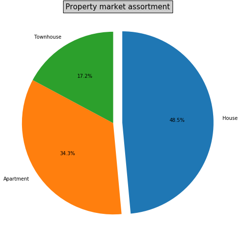

## Price Distribution of Gauteng residential properties

Property prices in the data used ranged from as low as R120,000 to millions of rands. On a logged scale, the distribution looks bimodal ud builds up to a bell shape peaking at around R650,000. Looking at price/m^2, there's a distinctive spike around 4,000/m^2 whilst most bulge around R10,000.

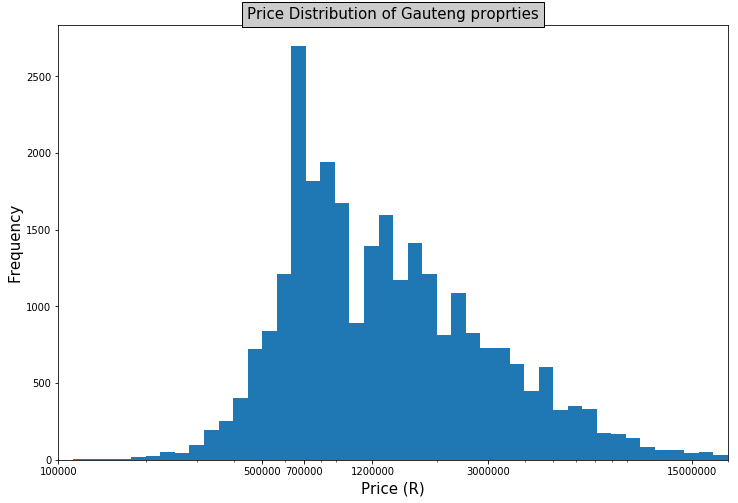

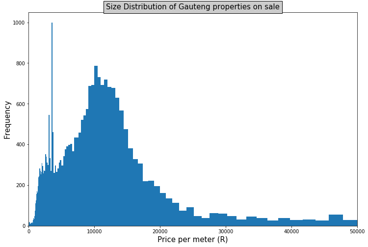

### Inverse relationship of by Price and Price per square meter by property type

Free standing houses are on average more expensive than other residential properties, followed by townhouses then the least expensive being apartments without considering the size. We can however notice an inverse relationship when it comes to price per square meter. Houses are the cheapest per square meter as they have bigger Erf size than the other 2 types. On the opposite end Apartments are the most expensive per square meter as they have smaller floor sizes. Townhouses are in between but towards the higher end of the apartment prices. Free standing houses have on average 3 bedrooms and 2 bathrooms which is similar to townshouses. There is also a noticeale bulge in 4 bedrooms for houese and 1 bathroom. Apartments have a great bulge in 2 bedrooms and 1 bathroom. They do however have noticeable bulges in in 1 and 3 bedrooms and 2 bathrooms.

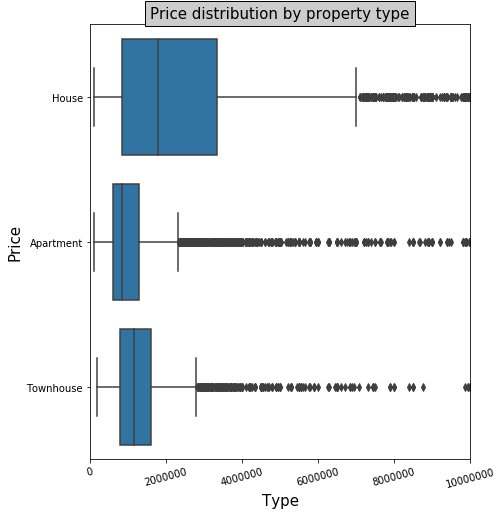

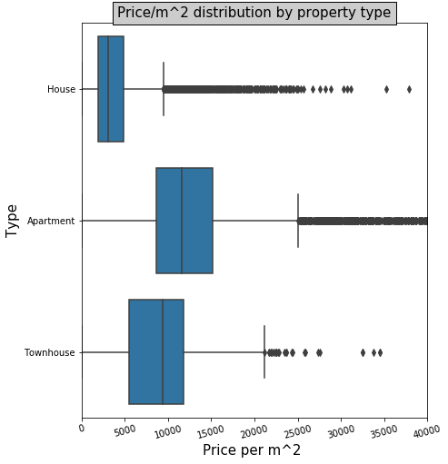

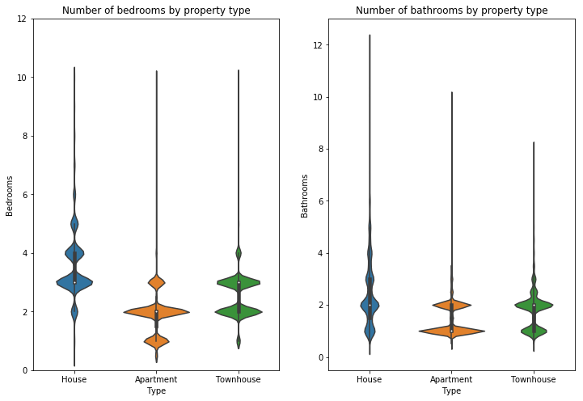

### Do rooms have an effect of property price?

There is a relatively high positive correlation between the number of rooms (both bath and bed) to the price of the property.

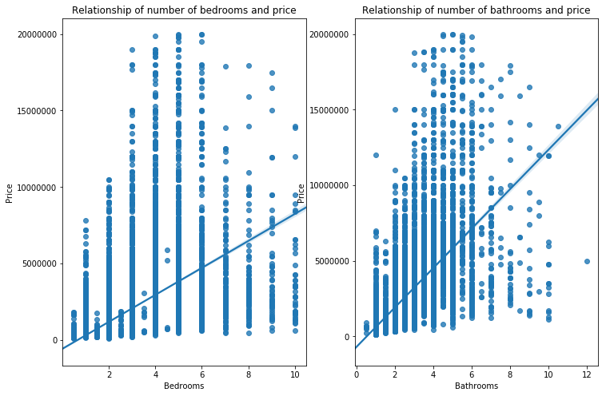

### Is there a relationship between property price reduction and under offers?

Seemingly not. None of the properties that are reduced have offers against them. We see under offeres on properties that kept their original entry price or they houses are not that attractive to buyers?

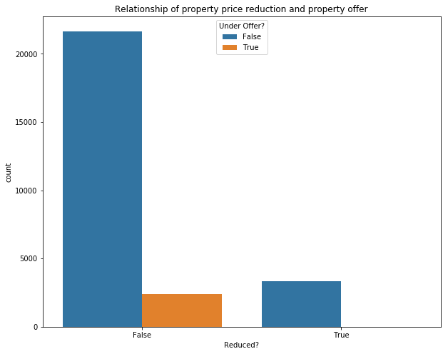

### What types of properties are people buying and where?

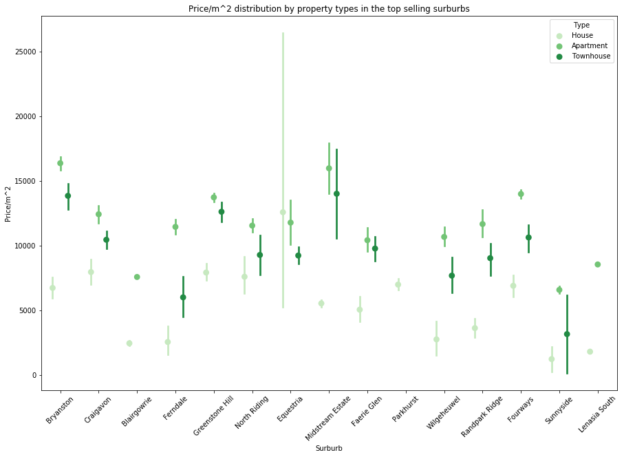

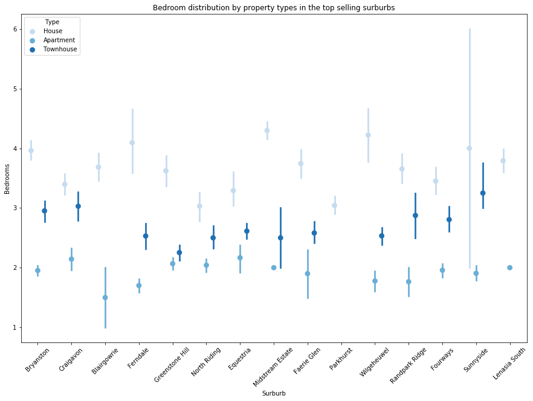